# stats_review

**Dragos Ailoae**

Applied Statistics and Econometrics I

2021-09-27

## Week 3 - Statistics Review

## Taking stock:

Concepts you should be comfortable with:

1. Expected value as an operator:
   - Prove that $E[a+bx]=a +b E[x]$ while $Var[a+bx]=b^2 Var[x]$
   - Prove that $Var[x]\equiv \sigma_{x}^{2}=E[x^2]-\mu_{x}^2$
   - Prove that $Cov[x,y] = E[xy]- \mu_x \mu_y$
2. Nomenclature: Mean, expected value, weighted mean, population mean, sample mean, arithmetic mean, average
3. Estimator properties: Unbiasedness, Efficiency, Consistency
   - See last week's [demo](https://ciresar.github.io/NYU/Lab_2/r_intro_sampling_probability_bias_v_consistency_v_efficiency) or for some more examples [here](https://en.wikipedia.org/wiki/Consistent_estimator#Unbiased_but_not_consistent)
4. Sample mean estimator properties. Just one of many unbiased estimators for the population mean and may not be the most efficient for every [distribution](https://math.stackexchange.com/a/3332055)
5. However, sample mean estimator has desirable properties even when the parent population distribution is unknown: Central Limit Theorem
   - See last week's [demo](https://ciresar.github.io/NYU/Lab_2/r_intro_sampling_probability_bias_v_consistency_v_efficiency) where we sampled from the normal distribution: convince yourself it works with other distributions
6. Continuous RVs
   - Unlike in the discrete case (PMFs) the y-axis is meaningless with PDFs i.e. we can have values > 1. See for example the normal distribution: as $\sigma_x$ goes to 0 the y-value $f(\mu_x)$ goes to infinity.
   - $P[x=X] = 0$
7. Normal distribution:
   - prove that if $X \sim N(\mu,\sigma)$ then the transformed variable $Z=\frac{X-\mu}{\sigma}$ is distributed as $Z\sim N(0,1)$
   - $\approx$ 2 standard deviations on either side of mean includes 95% of mass (actually 1.96 SDs)

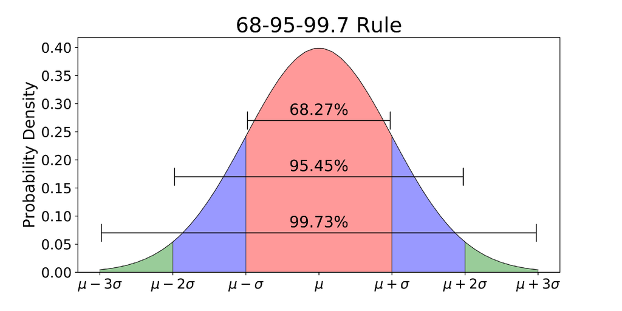

## Some exercises:

1. If $x$ has a normal distribution with mean 1 and standard deviation 3, what is $\operatorname{Prob}[|x|>2]$? You can find standard normal CDF tables [here](https://en.wikipedia.org/wiki/Standard_normal_table) or [here](https://ciresar.github.io/NYU/Lab_3/normal_cdf.pdf).
2. Let $X$ be a continuous random variable with probability density function (PDF) given by $$ f(x)= \begin{cases} \frac{1}{2} x, & 0 \leq x \leq 2 \\ 0, & \text { elsewhere }\end{cases} $$ a) Is $f(x)$ a valid PDF?

   b) A sample of this RV will likely show more samples where $x \leq 1$ or $x>1$?

   c) Find the cumulative distribution function $F(x)$.

   d) Find $\mu_x$ and $\sigma_x^2$.

## How R can help:

Every probability distribution that R handles has four basic functions whose names consist of a prefix followed by a root name. As an example, take the normal distribution. The root name of all four functions associated with the normal distribution is norm. The four prefixes are

- $d$ for "density" - probability function / probability density function
- $\mathrm{p}$ for "probability" - cumulative distribution function
- $q$ for "quantile" - quantile function (inverse cumulative distribution function)
- $r$ for "random"-random number generator Thus, for the normal distribution we have the $R$ functions dnorm (), pnorm (), qnorm( $)$ and rnorm ( ).

See [Base-R Cheat Sheet](https://ciresar.github.io/NYU/Lab_2/base_r_cs.pdf) for some other distributions:

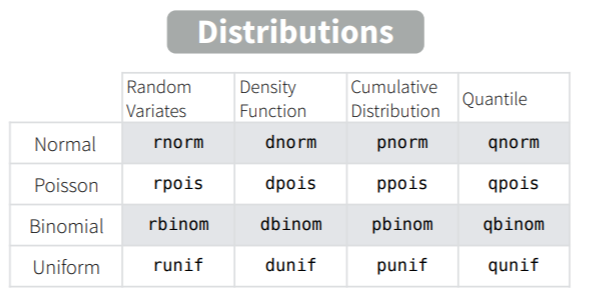

To draw a plot of the N(0,1) PDF:

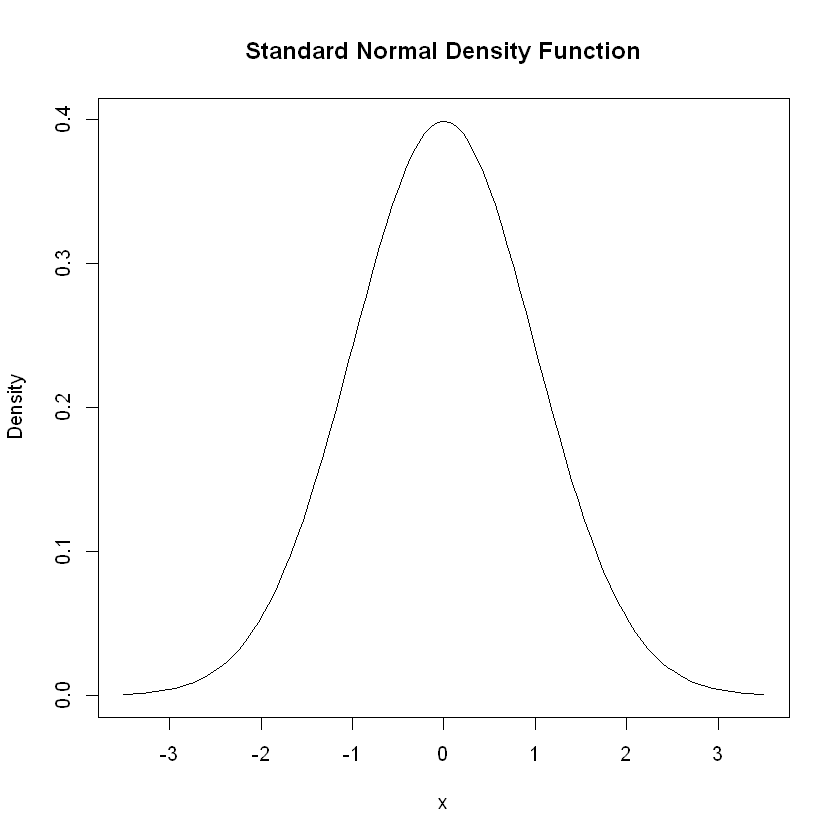

```r
curve(dnorm(x),
      xlim = c(-3.5, 3.5),
      ylab = "Density",
      main = "Standard Normal Density Function")
```

To compute density at x=-1.96, x=0 and x=1.96:

```r
dnorm(x = c(-1.96, 0, 1.96))
```

1. 0.0584409443334515

2. 0.398942280401433

3. 0.0584409443334515

To plot the standard normal CDF:

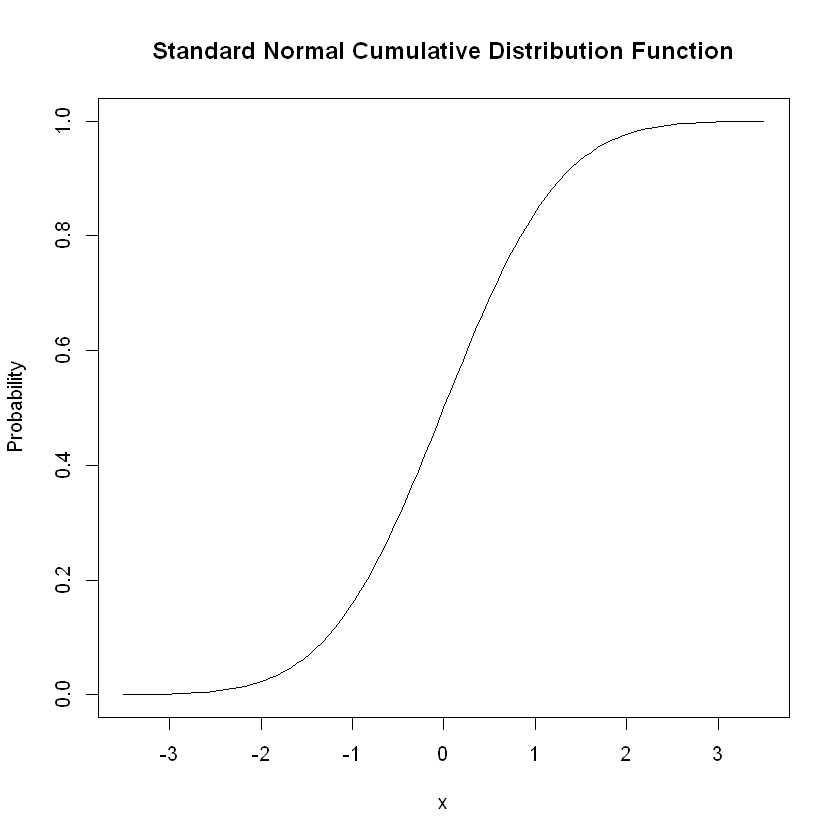

```r
curve(pnorm(x),
      xlim = c(-3.5, 3.5),
      ylab = "Probability",
      main = "Standard Normal Cumulative Distribution Function")
```

### To solve exercise 1 above (as an alternative to tables lookup):

```r
1 - (pnorm(1/3)-pnorm(-1))
```

0.528096594113221

### What about exercise 2?

Luckily, $R$ also enables us to easily find the results derived above. The tool we use for this is the function integrate ( ). First, we have to define the functions we want to calculate integrals for as $R$ functions, i.e., the PDF $f_{X}(x)$ as well as the expressions $x \cdot f_{X}(x)$ and $x^{2} \cdot f_{X}(x)$.

To define the functions:

```r
f <- function(x) x/2
g <- function(x) x * f(x)
h <- function(x) x^2 * f(x)
```

Next, we use integrate ( ) and set lower and upper limits of integration to 0 and $2$ using arguments lower and upper. By default, integrate ( ) prints the result along with an estimate of the approximation error to the console. However, the outcome is not a numeric value one can readily do further calculation with. In order to get only a numeric value of the integral, we need to use the $\$$ operator in conjunction with value. The $\$$ operator as we saw last week is used to extract elements by name from an object of type list.

To compute area under the density curve:

```r
area <- integrate(f,
                 lower = 0,
                 upper = 2)$value
area
```

1

This confirms we have a valid PDF.

```r
area.left <- integrate(f,
                 lower = 0,
                 upper = 1)$value
area.left
```

0.25

```r
area.right <- integrate(f,
                 lower = 1,
                 upper = 2)$value
area.right
```

0.75

To find the CDF function we integrate the PDF:

```r
options(warn=-1) # Suppress warnings
qui <- suppressPackageStartupMessages # quiet! - suppress library load messages

# install (if not already installed) and load package
qui(if(!require(mosaicCalc)){install.packages('mosaicCalc')})       # for antiD function - symbolic integral
fun <- antiD(x/2 ~ x )
fun
```

```
function (x, C = 0)
1/4 * x^2 + C
```

To find the mean:

```r
EX <- integrate(g,
                lower = 0,
                upper = 2)$value
EX
```

1.33333333333333

To find the variance:

```r
VarX <- integrate(h,
                  lower = 0,
                  upper = 2)$value - EX^2
VarX
```

0.222222222222222